# FigureYa1 SurvivalCurve

小丫画图出品 2018.4.29

微信ID: epigenomics Email: epigenomics@rainbow-genome.com

### 需求描述

网上搜到过代码，但是都是用TCGA自己带的肺癌数据画的，我需要用自己的数据绘制

### 使用场景

展示分类样本的生存曲线

场景一：患者的生存期跟基因变异的关系

场景二：药物处理导致模式动物生存期变化

### 输入数据

需求方提供的输入数据格式

```r
svData<-read.delim(file="survival_input.txt",header=T,as.is=T)
head(svData)
```

```
##   Months PD.L1.protein.high.expression PD.L1.protein.low.expression
## 1      1                            NA                            1
## 2      1                             1                           NA
## 3      1                            NA                            1
## 4      1                            NA                            1
## 5      4                            NA                            1
## 6      6                            NA                            1
```

```r
tail(svData)
```

```
##    Months PD.L1.protein.high.expression PD.L1.protein.low.expression
## 82    128                            NA                            0
## 83    132                            NA                            0
## 84    132                            NA                            0
## 85    132                            NA                            0
## 86    139                             0                           NA
## 87    140                            NA                            0
```

### 输入数据的格式化

画图用的数据结构是一个包含样本分类、生存期和追踪情况的数据框。

测试用数据的生存期是Months列，样本分类和追踪情况揉在第2和3列中，1代表death，0代表alive，NA和1/0代表样本分类，因此，样本分类和追踪情况需要重新生成

```r
svData$Expression<-NA
svData$Expression[!is.na(svData$PD.L1.protein.high.expression)]<-"high"
svData$Expression[is.na(svData$PD.L1.protein.high.expression)]<-"low"
svData$Status<-1+(!is.na(svData$PD.L1.protein.high.expression|svData$PD.L1.protein.low.expression))
head(svData[,c(1,4,5)])
```

```
##   Months Expression Status
## 1      1        low      2
## 2      1       high      2
## 3      1        low      2
## 4      1        low      2
## 5      4        low      2
## 6      6        low      2
```

```r
write.table(svData[,c(1,4,5)],file="easy_input.txt",sep = "\t",col.names = T,row.names = F,quote = F)
```

可以看到重新生成后，svData中生存期、样本分类和追踪情况分别是Months、Expression、Status列。

多说一句，追踪信息遵循的规则是，The status indicator, normally 0=alive, 1=dead. Other choices are TRUE/FALSE (TRUE = death) or 1/2 (2=death)

如果输入文件格式跟easy_input.txt相符，就跳过上面调整格式的步骤。

### 开始画图

常见调整参数有颜色、线的类型、是否显示置信区间等

用?ggsurvplot查看更多参数设置

```r
#install.packages(c("survival","survminer"))
library("survival")
library("survminer")
```

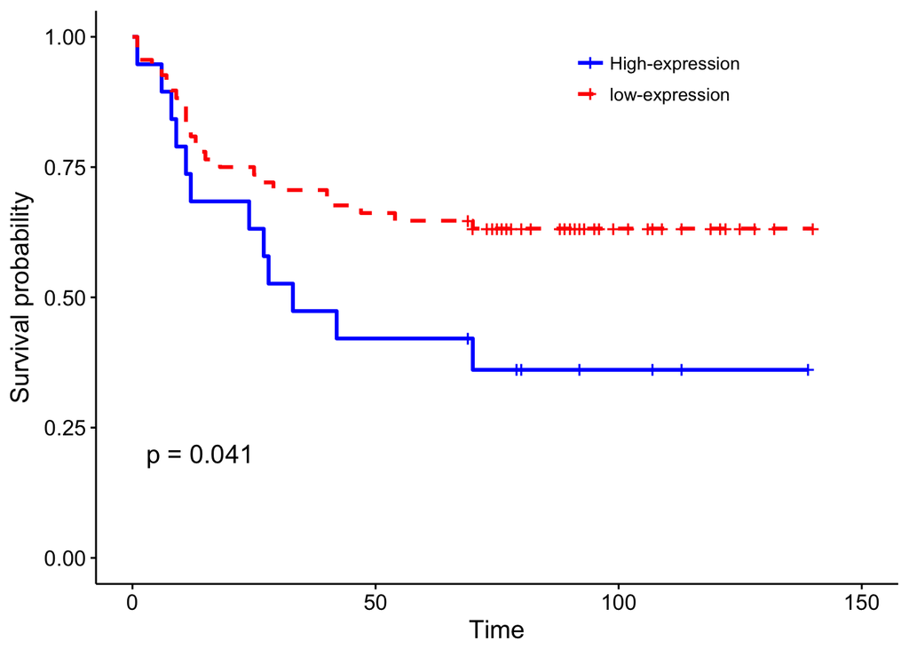

```r
fit<- survfit(Surv(Months, Status) ~ Expression, data = svData)
ggsurvplot(fit, pval = TRUE,linetype = c("solid", "dashed"), #线的类型
           palette = c("blue","red"),#线的颜色
           legend.title="",legend=c(0.7,0.9),legend.labs=c("High-expression","low-expression"),
           conf.int = F) #不显示置信区间
```

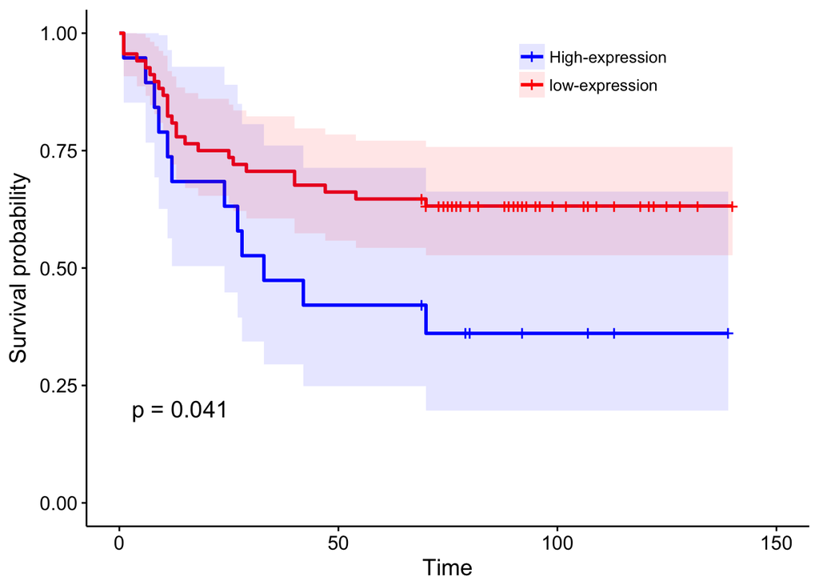

```r
ggsurvplot(fit, pval = TRUE, linetype = "solid",
           palette =c("blue","red"),
           legend.title="",legend=c(0.7,0.9),legend.labs=c("High-expression","low-expression"),
           conf.int = T,#显示置信区间
           conf.int.style="ribbon",#展示方式
           conf.int.alpha=0.1)#透明度
```

```r
ggsave(file="survivalcurve.pdf")
```

输出的pdf文件是矢量图，可以在Illustrator等软件里进行字体、字号等编辑操作